# Reproducible Research: Peer Assessment 1

## Loading and preprocessing the data

Data was supplied in zipped format from the original repo fork. First I will unzip it and load it into R. Then I will turn the date into a date.

```r
unzip("activity.zip")
df = read.csv("activity.csv")

library(lubridate) # For ymd()
df$date = ymd(as.character(df$date))
```

## What is mean total number of steps taken per day?

Per instructions, get the mean and median steps per day (ignoring NAs).

Steps: 1. Get sum of all steps on each day

```r
library(dplyr) # For slicing/dicing convenience
spd = df %>% group_by(date) %>%
  summarise(totsteps=sum(steps, na.rm=TRUE))
```

2. Produce a histogram of steps per day

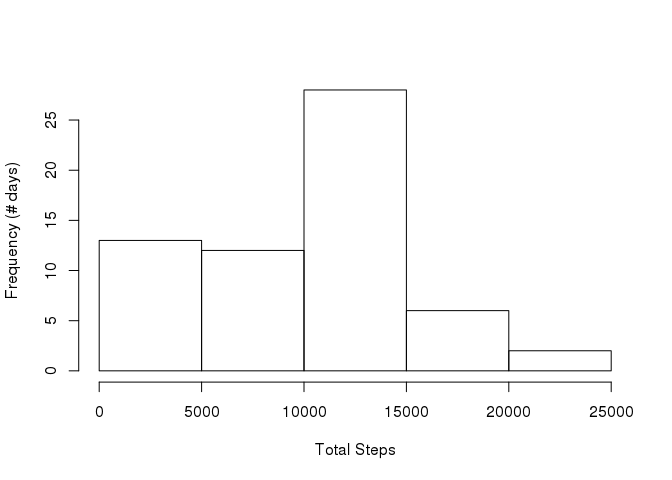

```r
hist(spd$totsteps, main="", xlab="Total Steps", ylab="Frequency (# days)")
```

3. The mean and median steps per day (with NAs treated as 0s)

```r
mn = mean(spd$totsteps)
mdn = median(spd$totsteps)
```

The mean is 9354.2295082 steps/day and median is 10395 steps/day.

## What is the average daily activity pattern?

1. Produce a plot of the average (over all days) number of steps per 5-minute interval. To do this, I make a summary table of steps per interval/number of days (as above, this calculation will be biased by missing measurements).

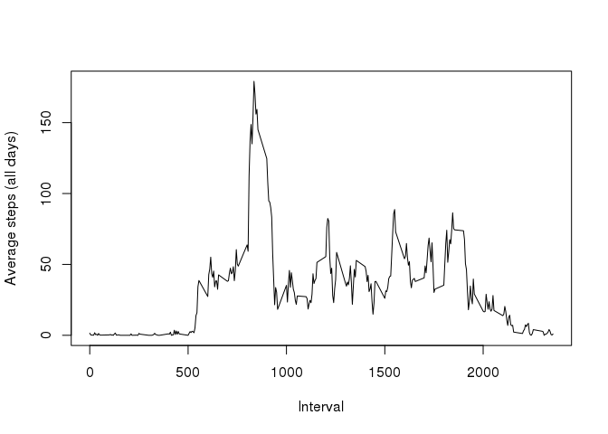

```r
ndays = length(spd$date)
spi = df %>% group_by(interval) %>%
  summarise(totsteps=sum(steps, na.rm=TRUE), avgsteps=sum(steps, na.rm=TRUE)/ndays)

plot(spi$interval, spi$avgsteps, type="l",
     xlab="Interval", ylab="Average steps (all days)")
```

2. To find the interval with maximum average steps:

```r
maxavgsteps = max(spi$avgsteps)
maxint = spi$interval[spi$avgsteps==maxavgsteps]
```

Interval id with max steps: 835

## Imputing missing values

1. Get the missing number of rows with missing values

```r
miss = is.na(df$steps)
misscount = sum(miss)
```

There are 2304 intervals with NA steps.

2. I will fill in the missing values with the average for the time interval (noting that this is a scientifically sketchy thing to do unless we understand why the values are missing).

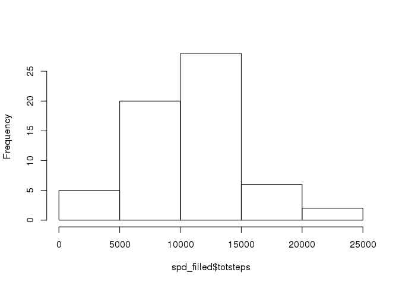

```r
df$fillsteps = df$steps
for (i in 1:length(df$fillsteps)){
  intr = df$interval[i]
  if(is.na(df$fillsteps[i])){
    df$fillsteps[i]=spi$avgsteps[spi$interval==intr]
    }
  else {
    df$fillsteps[i]=df$fillsteps[i]
    }
}
df_filled = df[,c("fillsteps", "date", "interval")]
colnames(df_filled) = c("steps", "date","interval")

spd_filled = df_filled %>% group_by(date) %>%
  summarise(totsteps = sum(steps))

mn_filled = mean(spd_filled$totsteps)
mdn_filled = median(spd_filled$totsteps)

hist(spd_filled$totsteps, main="")
```

## Are there differences in activity patterns between weekdays and weekends?

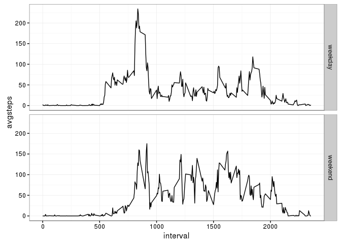

```r
library(ggplot2)
df$weekend = ifelse(weekdays(df$date) %in% c("Saturday","Sunday"), "weekend", "weekday")
df$weekend = as.factor(df$weekend)
spi_day = df %>% group_by(interval, weekend) %>%
  summarise(avgsteps = mean(steps, na.rm=TRUE))
spi_day %>% ggplot()+geom_line(aes(x=interval, y=avgsteps))+
  facet_grid(weekend~.)+theme_bw()
```

Yes, there are differences between weekends and weekdays.